# Snakemake working group

# Snakemake working group

2024-10-15

Nadia GOUE, Sébastien RAVEL, Chloé QUIGNOT

Source: adapted from FAIRbioinfo 2021 training material of the [IFB](https://moodle.france-bioinformatique.fr/course/view.php?id=5) and Snakemake introduction tutorial from [BIOI2](https://bioi2.i2bc.paris-saclay.fr/training/snakemake)

Material under [CC-BY-SA](https://creativecommons.org/licenses/by-sa/2.0/fr/deed.fr) licence

[figure not shown]

# How this working group is organised

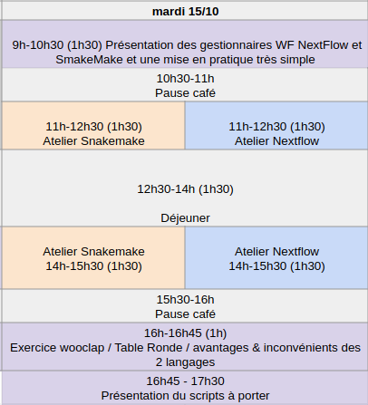

“Today’s timetable”

- Divided into 2 sessions of 1h30 each
- A single continuous but progressive exercise over these 2 sessions
- Presentation of a use-case by Pauline @2pm (~30min)

# What the exercise is about

- You’ll be building a Snakemake pipeline from scratch
- The exercise will be divided into several parts and you’ll be guided along the way
  - Part A: create a first simple pipeline with FastQC & MultiQC tools

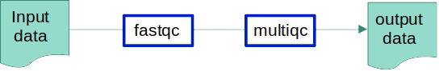

    - Inputs: NGS data (`*.fastq.gz`)
    - Processing: individual QC analyses with FastQC and aggregation of results with MultiQC
    - Output: Quality Control report
  - Part B: improve the previous pipeline
  - Part C: adapt the previous pipeline to the HPC environment

*Don’t worry about understanding what QC analysis does*

Snakemake’s FAQ: https://snakemake.readthedocs.io/en/latest/project_info/faq.html

# It’s time to get your hands dirty!

Go to the Moodle web page and open up instructions for exercise A.

https://moodle.france-bioinformatique.fr/course/view.php?id=29

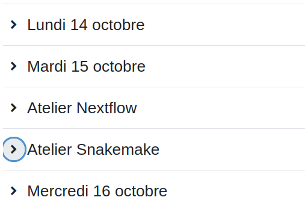

# A few reminders

- Snakemake workflow = set of rules
- Snakefile = where snakemake code is written
- Rules are defined by their name and contain directives (of which `input` and `output` to specify input & output files):

```
rule myRuleName
    input: "myInputFile"
    output: "myOutputFile"
    shell: "echo {input} > {output}"
```

- Snakemake only executes the target rule and only rules that will help in generating its files
- Rules can be generalised using `wildcards` written within braces (e.g. `{wildcardname}`)
- A Snakefile is run with the `snakemake --cores 1` command (+ other options available)
- Debugging options: `--dag`, `--rulegraph`, `--filegraph` and `--dry-run` + `-p` to print shell commands